# TP2 Tests Statistiques

Lancelot Ravier

2024-12-09

Le jeu de données `ozone.csv` provient de l’association Air Breizh. L’une des missions de ces associations de surveillance de la qualité de l’air est de construire des modèles de prévision de la concentration en ozone, pour anticiper un dépassement légal du pic d’ozone (180 $\mu$g/m$^3$). L’objectif des données récoltées dans ce jeu de données est de mettre en évidence l’influence de certains paramètres sur la concentration d’ozone.

Les 13 variables observées sont :

- `maxO3`: Maximum de concentration d’ozone observé sur la journée ($\mu$g/m$^3$)
- `T9, T12, T15` : Température observée à 9, 12 et 15h
- `Ne9, Ne12, Ne15` : Nébulosité observée à 9, 12 et 15h
- `Vx9, Vx12, Vx15` : Composante Est-Ouest du vent à 9, 12 et 15h
- `maxO3v` : Teneur maximum en ozone observée la veille
- `vent` : orientation du vent à 12h
- `pluie` : occurence ou non de précipitations

La question principale est l’étude de la dépendance du maximum de concentration d’ozone observé sur la journée avec les autre variables.

# 1) Statistiques descriptives

Afin d’analyser les variable de notre base de données, débutons par construitr un tableau récapitulatif de nos données avec les principaux indicateurs de statistiques descriptives (min, max, moyenne, ecart-type, mediane, densités, valeurs manquantes) à l’aide du package *modelsummary*.

|  | Unique (#) | Missing (%) | Mean | SD | Min | Median | Max |  |
| --- | --- | --- | --- | --- | --- | --- | --- | --- |
| maxO3 | 61 | 0 | 90.3 | 28.2 | 42.0 | 81.5 | 166.0 |  |
| T9 | 70 | 0 | 18.4 | 3.1 | 11.3 | 17.8 | 27.0 |  |
| T12 | 78 | 0 | 21.5 | 4.0 | 14.0 | 20.6 | 33.5 |  |
| T15 | 81 | 0 | 22.6 | 4.5 | 14.9 | 22.1 | 35.5 |  |
| Ne9 | 9 | 0 | 4.9 | 2.6 | 0.0 | 6.0 | 8.0 |  |
| Ne12 | 9 | 0 | 5.0 | 2.3 | 0.0 | 5.0 | 8.0 |  |
| Ne15 | 9 | 0 | 4.8 | 2.3 | 0.0 | 5.0 | 8.0 |  |
| Vx9 | 65 | 0 | −1.2 | 2.6 | −7.9 | −0.9 | 5.2 |  |
| Vx12 | 67 | 0 | −1.6 | 2.8 | −7.9 | −1.9 | 6.6 |  |
| Vx15 | 66 | 0 | −1.7 | 2.8 | −9.0 | −1.5 | 5.0 |  |
| maxO3v | 62 | 0 | 90.6 | 28.3 | 42.0 | 82.5 | 166.0 |  |

#### 1.1) Analyse des variables de température, nébuleuse et composante Est-Ouest du vent

Les mesures de température, nébulosité et composante est-ouest du vent étant quantitatives continues, nous pouvons les analyser à l’aide de boxplots. Le graphique sera constitué de 3 figures dans lesquelles seront représenté 3 boxplot pour les 3 horaires de mesure (9h, 12h et 15h).

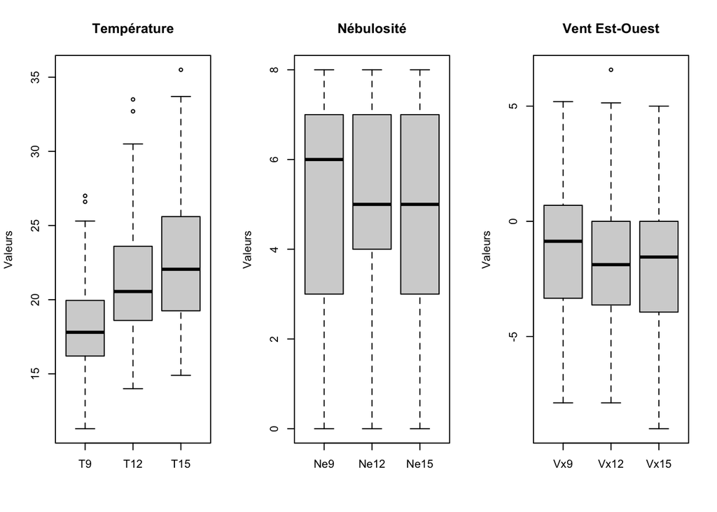

**Pour la variable température :**

En moyenne, les températures sont croissante entre 9h et 15h : les températures les plus basses ont été mesurées à 9h et les températures les plus hautes à 15h. L’écart moyen entre 12h et 15h est plus faible que celui entre 9h et 12h. L’intervalle interquartile ainsi que la médiane sont croissantes entre 9h, 12h et 15.

**Pour la nébulosité :**

L’écart inter-quartile est simmilaire pour les 3 mesures, malgré une médiane plus haute à 9h. Les moyennes sont quasi-égales à ces 3 horaires.

**Pour la composante du vent est-ouest :**

Toutes les données de statistiques descriptives (les données )moyennes, médianes, distributions, sont quasi-égales.

#### 1.2) Analyse de la variable pluie

Pour analyser la variable pluie (qualitative), nous allons représenter un barplot pour chaque modalité (pluie, sec) et analyser les effectifs.

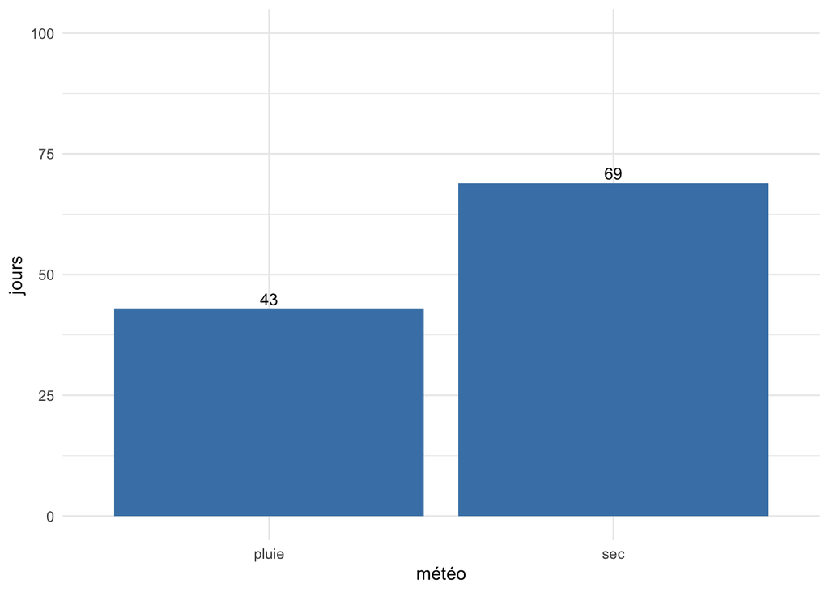

Notre base de donneés a mesuré 43 jours de pluie, ainsi que 69 jours où le temps était sec.

#### 1.3) Analyse de la variable vent

De mème que pour la variable pluie, nous allons analyser les effectifs pour les différentes orientations du vent (est, ouest, nord, sud) à l’aide d’un barplot.

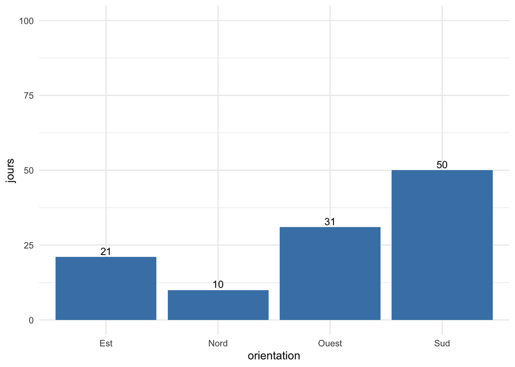

21 jours ont été mesurés aevc un vent soufflant à l’est, 10 jours au nord, 31 jours vers l’ouest et 50 jours au sud. Nous devons ètre vigilant lors de l’utilisation de tests paramétriques sur la variable vent car certaines modalités sont inférieures à 30 : ainsi, la convergence pourrait ne pas ètre valable.

# 2) Analyses bivariées :

#### 2.1) Analyse de l’effet de maxO3v sur maxO3

La base de données étant en série temporelle, la significativité des tests individuels (Student, Fisher) pourrait ètre faussée à cause de termes d’erreurs heteroscedastiques ou autocorrélés dans le temps, induisant une mauvaise estimations des écarts-types et un mauvais calcul des tests qui en découlent. Dans notre cas, il est très probable que la mesure d’ozone d’un jour donné soit corrélée à la mesure d’ozone de la veille en raison de la continuité des des phénomènes météorologiques et des réactions chimiques dans l’atmosphère. Si cette relation n’est pas inclue dans notre modèle (et, donc, dans le terme d’erreur), notre modèle ignorera une part importante de la structure temporelle des données, en plus d’omettre une variable expliquant probablement une grande partie de la variance.

La création d’un modèle linéaire simple* entre maxO3 et maxO3v montre que cette variable explique, à elle seule, $46\%$ de la variance totale, justifiant ainsi son importance dans la validation de l’hypothèse d’indépendance entre l’erreur et les variables exogènes ($H_5:cov(X_i, \epsilon_j)=0,\forall i\neq j$), ainsi que l’hypothèse d’autocorrélation des erreurs ($H_4:cov(\epsilon_i, \epsilon_j)=0,\forall i \neq j$).

*L’utilisation d’ecarts-types robustes n’est pas nécessaire ici malgré la présence d’heteroscédasticité des perturbations car aucune p-valeur n’est interprétee.

#### 2.2) Analyse des différences entre le maximum de concentration d’ozone des jours avec et sans pluie

Cette différence peut ètre analysée à l’aide d’un graphique (construit avec *ggplot2*) dans lequel les densités des deux modalités (selon maxO3) seront représentées. Ainsi, nous pourrons mener une première analyse visuelle des différences de maxO3 entre ces deux météos.

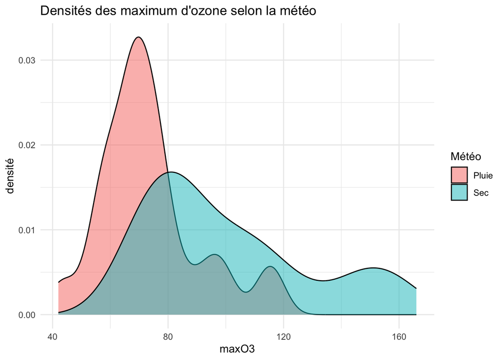

D’après ce graphique des densités, les distributions des deux groupes ont l’air visuellement différentes. Afin de verifier cette différence, nous pouvons réaliser un test d’égalité des moyennes pour le groupe $Pluie$ et $Sec$. Le test de Welch est adapté dans notre cas car les effectifs des deux groupes sont assez élevés ($n>30$) ce qui induit une convergence des distributions vers des distributions normales selon le TCL.

Selon le test de Welch, l’écart entre les moyennes des deux populations est significatif au seuil $\alpha = 5\%$. Il existe donc une différence significative entre le maximum de concentration d’ozone entre les jours de pluie et les jours sec. La variable pluie pourrait donc apporter une information supplémentaire dans notre modèle final car cette dernière modélise une différence de mesure du maxO3 durant les jours de pluie.

Cependant, la pluie peut avoir un effet sur certaines conditions météorologiques comme la température ou la nébulosité. Ainsi, la pluie pourrait apporter une information individuelle moindre que ces variable lors de la constitution d’un modèle multiple, réduisant ainsi sa significativité. L’intuition derrière ce lien pourrait se traduire par une performance plus élevée d’un modèle dont on supprimerait la pluie au profit d’autres variables plus précise comme la nébulosité ou la température, expliquant elles-mème une partie de l’information apportée par la pluie, dans le cas où la température et la nébulosité expliquent significativement le maximum d’ozone.

#### 2.3) Analyse du lien entre la concentratin maximale d’ozone et la température/la nébulosité/la force du vent Est-Ouest

La base de données fournit les données de température, de nébulosité et de force du vent Est-Ouest pour 3 horaires : 9:00, 12:00 et 15:00. Après analyse des corrélations inter-variables, nous voyons que celles-ci sont toutes corrélées au max de concentration d’ozone, la température et la composition du vent étant coréllées positivement tandis que nébulosité est coréllés négativement (T12 et Vx9 sont les plus coréllés positivement, Ne12 est la plus corrélés négativement). Cependant, les variables sont aussi très coréllés entre-elles. Ainsi, la composition d’un modèle linéaire avec la totalité des variables induierait une certaine redondance de l’information. Afin d’analyser l’heure à laquelle les 3 variables (température, nébulosité et force du vent) expliquent le mieux le maxO3, nous allons constituer des modèles MCO et comparer les significativités des variables pour les 3 horaires. Ainsi, le choix des variables se fera selon leur significativité. Après constitution des premires modèles, les tests de Breuch-Pagan et de Durbin-Watson ont indiqué la présence d’heteroscédasticité et d’autocorrélation positive des perturbations pour les 3 modèles. Ainsi, afin de permettre le respect de l’hypothèse $H_3:Var(\epsilon_i) = \sigma^2, \forall i$, nous avons recalculé les p-valeurs en utilisant les ecarts-types robustes calculés avec la correction de white1 de type HC1. Aussi, afin de permettre le respect des hypothèses $H_3$ et $H_5$, nous ajoutons la variable maxO3v dans nos modèles. Ainsi voici un graphique représentant les intervalles de confiances des variables de température/nébulosité/composante est-ouest/maxO3v pour les 3 modèles, heteroscédasticité et autocorrélation des résidus corrigés (construit à l’aide du package *dotwhisker*:

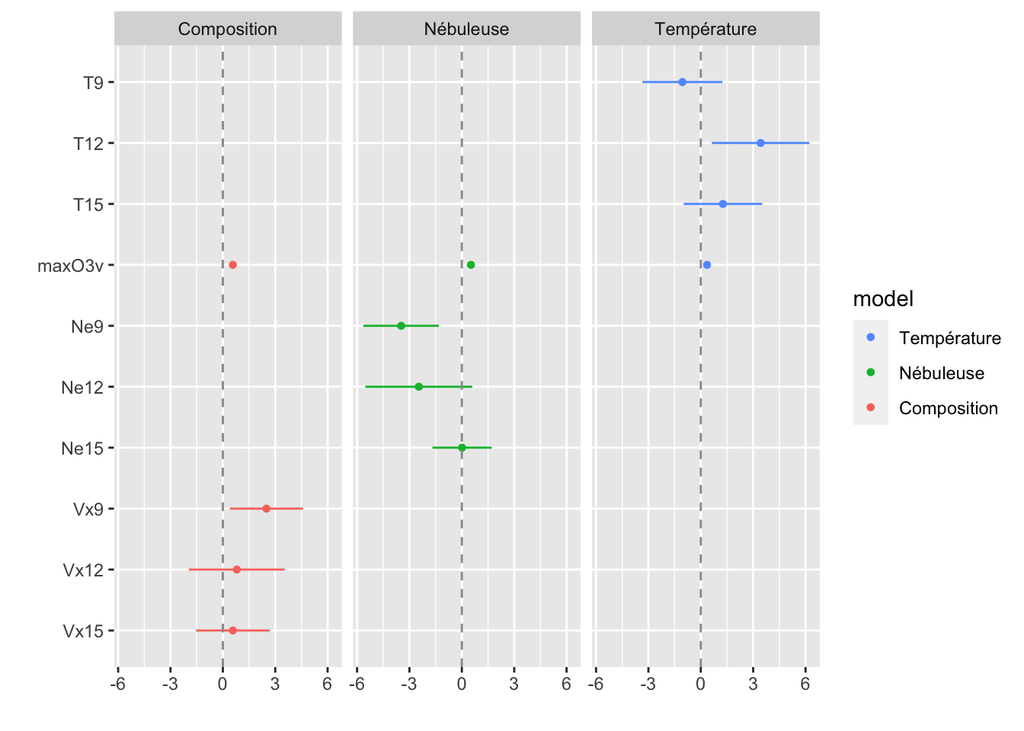

D’après ces 3 modèles, en analysant les significativités à l’aide des intervalles de confiance ($\alpha = 5\%$) : Sur les données de température, la température à 12:00 apporte la plus grande quantité d’information unique au modèle. Pour les données de nébulosité et de composition du vent est-ouest, c’est les donnéees recueuillies à 9:00 qui apportent le plus d’information individuelle. Ces 3 variables ont donc la plus grande part unique de variance expliquée, en comparaison avec les deux autres horaires mesurés pour chacune d’elles.

#### 2.4) Analyse de l’influence de la diréction du vent sur la concentration maximale d’ozone

Afin d’analyser l’effet de la diréction du vent sur maxO3, nous pouvons procéder en vérifiant les différences de maxO3 selon les différentes orientations du vent à l’aide d’un boxplot représentant les 4 modalités. S’il existe une différence significative de maxO3 entre deux groupes, alors ces orientations du vent auront un effet significatif sur maxO3.

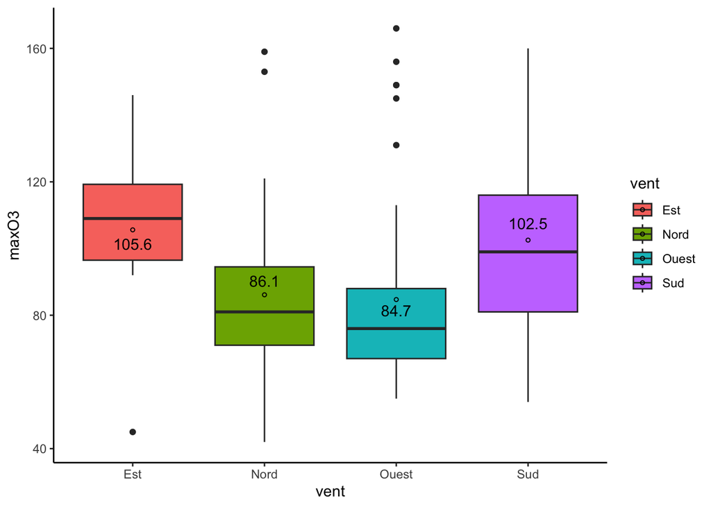

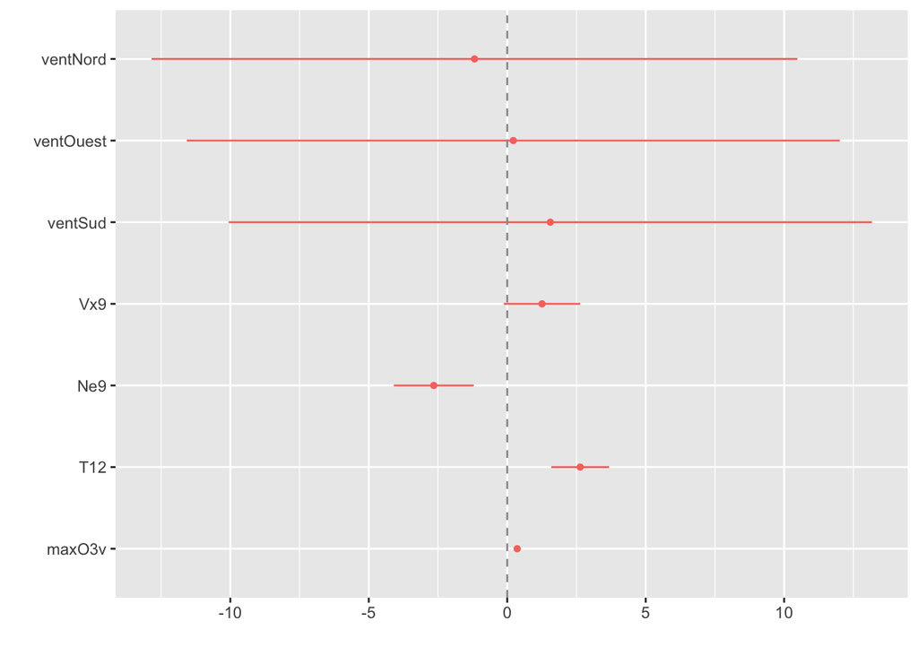

Après verification du respect des hypothèses $H_3$ d’homoscedasticité, $H_4$ de non autocorrélation, $H_5$ d’indépendance du terme d’erreur et du nombre d’observations $n>30$ induisant la convergence asymptotique en loi du terme d’erreur vers une loi normale impliquant le respect de l’hypothèse $H_6:\epsilon \sim \mathcal{N_n}(0, \sigma^2I_n)$, nous pouvons analyser les significativités des estimateurs de notre modèle.

Les significativités individuelles montre bien l’apport miondre d’information individuelle de l’orientation du vent pour expliquer maxO3 face aux autres estimateurs, malgré les réusltats trouvés lors des tests effectués sur la variable elle-même (la significativité réduite de la composition du vent Est/Ouest à 9:00 ($10\% < p = 7\% < 5\%$) est probablement due à l’apport d’niformation simmilaire entre cette variable et la variable liée à la diréction du vent. Ainsi, Vx9 redeviendra très probablement significative lors de la constitution du modèle final sans la variable vent).

# 3) Meilleur modèle et validation des hypothèses

#### 3.1) Constitution du modèle final

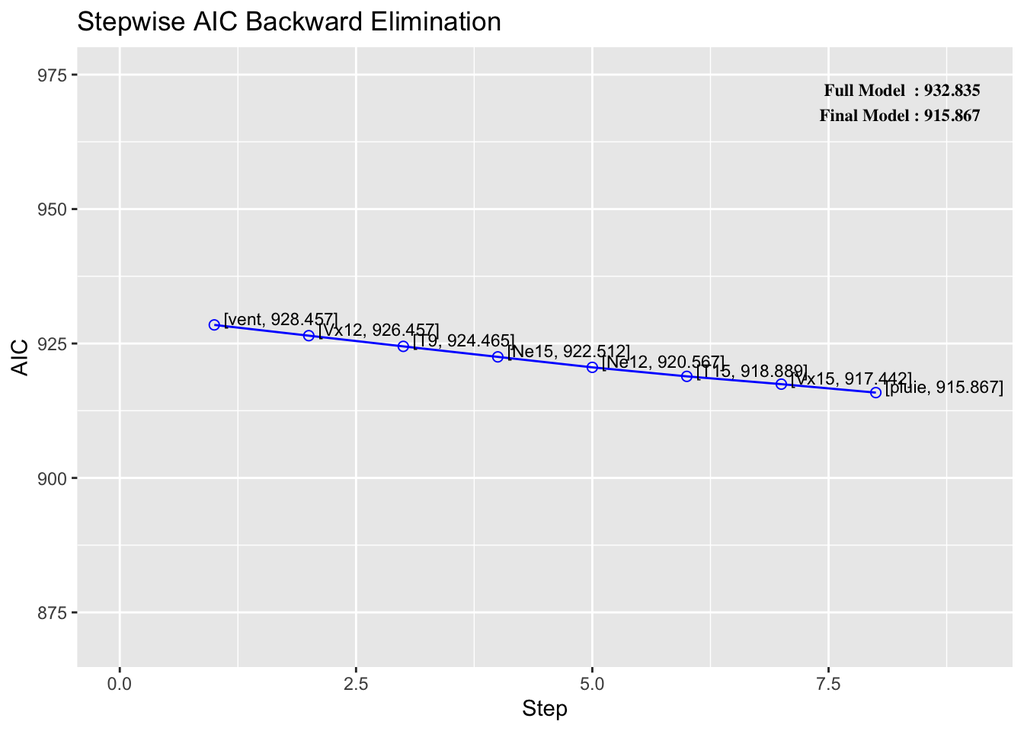

La fonction step commence par omettre la variable $vent$. Ce choix d’omission illustre bien l’apport moindre d’information et la redondance de l’information apportée par cette variable face aux variables de température et de nébulosité qui apporte une précision supplémentaire car représentant des mesures dans trois moments différents de la journée. Ensuite, la fonction trie les données de température, de néébulosité et de composition du vent en ne gardant que les mesures les plus influentes, les mesures apportant le plus d’information individuelle face aux autres mesures. Finalement, après avoir gardé 3 des variables T/Vx/Ne donnant le plus d’information dans le modèle, la fonction supprime la variable $pluie$ : malgré que cette dernière apporte une information individuelle plus complète que la totalité des variables T/Vx/Ne réunies (créeant une redondance de l’information), $pluie$ devient moins informative que les variables séléctionnéess ensemble, ces 3 sernières apportant une information individuelle plus importante.

Ainsi, le modèle final nous permet d’expliquer maxO3 par : - La température à 12:OO (T12) - La nébuleuse à 9:00 (Ne9) - La composition du vent est/ouest à 9:00 (Vx9) - le max d’ozone du jour d’avant (maxO3v)

Tout les résultats de notre modèle sont significatifs, excepté la constante.

#### 3.2) Performance du modèle et validation des hypothèses de Gauss-Markov

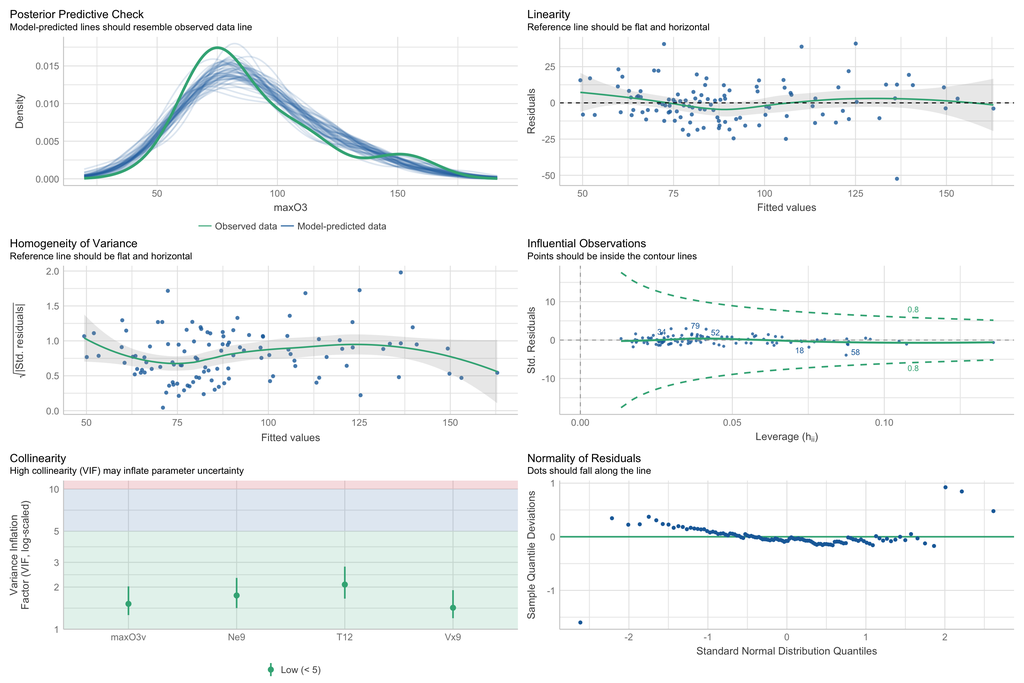

**Prédictions du modèle**  
D’après le graphique *Posterior Predictive Check*, nos prédictions sont proches des valeurs observées. Notre modèle est donc performant dans l’ensemble.

**Linéarité des résidus**  
D’après le graphique *Linearity*, nos résidus semble suivre une tendance linéaire malgré quelques variations.

**Variance homogène**  
D’après le graphique *Homogeneity of Variance*, les perturbations sont heteroscédastiques.

**Observations influentes**  
D’après le graphique *Influential Observations*, aucune observation influe la variance de manière significative.

**Colinéarité**  
D’après le graphique *Colinearity*, aucune variable n’est significativement colinéaire dans notre modèle.

**Normalité des résidus**  
D’après le qqplot, nos résidus ne suivent pas exactement une loi normale.

# Conclusion

En conclusion, nous avons constitué notre meilleur modèle à partir des intuitions des analyses individuelles et bivariées des variables explicatives selon le max d’ozone. Après vérification, nous avons vù que notre modèle ne respecte pas exactement les hypothèses de Gauss-Markov. Cependant, ce dernier reste performant. En effet, nos résidus ne suivent pas exactement une loi normale mais ils s’en rapprochent. De plus, l’interprétation de la significativité des paramètres du modèle ont ete calculés avec la matrice de variance-covariance corrigée de l’heteroscédasticité (non représentée sur le grahique 3). Ainsi, cette correction couplée à l’absence d’autocorrélation des résidus (test de Durbin-Watson non significatif) nous permet tout de même d’interpréter les résultats de notre régression. Enfin, les prédictions de notre modèle sont proches des valeurs observées : notre modèle est donc performant car nos prédictions convergent vers les observations.

# myt.test

```r
myt.test <- function(x, y = NULL, alternative = "two.sided", mu = 0, paired = FALSE, var.equal = FALSE, conf.level = 0.95) {
  # Vérification des arguments
  if (!is.numeric(x)) stop("x doit être un vecteur numérique")
  if (!is.null(y) && !is.numeric(y)) stop("y doit être un vecteur numérique")
  if (!is.numeric(mu)) stop("mu doit être un nombre réel")

  # Initialisation des variables
  method <- ""
  df <- 0
  t_statistic <- 0
  p_value <- 0

  # Préparation des données
  if (is.null(y)) {
    # Test à un échantillon
    n <- length(x)
    df <- n - 1
    mean_x <- mean(x)
    sd_x <- sd(x)
    stderr <- sd_x / sqrt(n)
    t_statistic <- (mean_x - mu) / stderr
    method <- "One Sample t-test"
  } else {
    # Test à deux échantillons
    if (paired) {
      if (length(x) != length(y)) stop("Pour un test apparié, x et y doivent avoir la même longueur")
      d <- x - y
      n <- length(d)
      df <- n - 1
      mean_d <- mean(d)
      sd_d <- sd(d)
      stderr <- sd_d / sqrt(n)
      t_statistic <- (mean_d - mu) / stderr
      method <- "Paired t-test"
    } else {
      n1 <- length(x)
      n2 <- length(y)
      mean_x <- mean(x)
      mean_y <- mean(y)
      var_x <- var(x)
      var_y <- var(y)

      if (var.equal) {
        # Variances égales (Student)
        pooled_var <- ((n1 - 1) * var_x + (n2 - 1) * var_y) / (n1 + n2 - 2)
        stderr <- sqrt(pooled_var * (1/n1 + 1/n2))
        df <- n1 + n2 - 2
        method <- "Student two sample t-test"
      } else {
        # Variances inégales (Welch)
        stderr <- sqrt(var_x / n1 + var_y / n2)
        df <- (stderr^4) / (((var_x / n1)^2 / (n1 - 1)) + ((var_y / n2)^2 / (n2 - 1)))
        method <- "Welch two sample t-test"
      }
      t_statistic <- (mean_x - mean_y - mu) / stderr
    }
  }

  # Calcul des p-valeurs
  if (alternative == "two.sided") {
    p_value <- 2 * pt(-abs(t_statistic), df)
  } else if (alternative == "less") {
    p_value <- pt(t_statistic, df)
  } else if (alternative == "greater") {
    p_value <- 1 - pt(t_statistic, df)
  } else {
    stop("alternative doit être 'two.sided', 'less' ou 'greater'")
  }

# Résultats

  result <- list(
    method = method,
    alternative = alternative,
    statistic = t_statistic,
    df = df,
    p.value = p_value
  )
  return(result)
}
```

Afin de verifier le bon fonctionnement de la fonction *myt.test*, regardons si les résultats sont égaux à ceux de la fonction t.test, pour les 8 cas ($H_0, H_1$ verifiéé pour chaque *method*). Pour ce faire, nous allons coder une fonction renvoyant TRUE si les statistiques de test et les p_valeurs des fonctions t.test et myt.test sont égales, FALSE sinon. Ensuite, nous allons, pour les 4 types de tests, générer les échantillons à l’aide de la fonction *rnorm* répondant aux critères des différents tests, sous $H_0$ et sous $H_1$.

```
## Cas 1 : Test à un échantillon, H0 vérifiée
##  TRUE
```

```
## Cas 2 : Test à un échantillon, H1 vérifiée
##  TRUE
```

```
## Cas 3 : Test Welch à deux échantillons, H0 vérifiée
##  TRUE
```

```
## Cas 4 : Test Welch à deux échantillons, H1 vérifiée
##  TRUE
```

```
## Cas 5 : Test apparié, H0 vérifiée
##  TRUE
```

```
## Cas 6 : Test apparié, H1 vérifiée
##  TRUE
```

```
## Cas 7 : Test Student à deux échantillons, H0 vérifiée
##  TRUE
```

```
## Cas 8 : Test Student à deux échantillons, H1 vérifiée
##  TRUE
```

Nous pouvons voir que, pour l’ensemble des cas, la fonction *myt.test* donne exactement les mêmes résultats que la fonction *t.test*.